# Old forest

NO_BGSK_001

Authors

Affiliations

Aud Helen Halbritter

University of Bergen

Ulrika Jansson Asplund

Norwegian Institute for Nature Research

Mari Jönsson

Norwegian Institute for Nature Research

Erik Framstad

Norwegian Institute for Nature Research

Oliver Snoksrud

Norwegian Institute of Bioeconomy Research

Ken Olaf Storaunet

Norwegian Institute of Bioeconomy Research

Published

February 12, 2026

Reviewed by

Matthew Grainger

> Recommended citation: Halbritter, A. H., Jansson Asplund, U., Jönsson, M., Framstad, E., Snoksrud, O., and Storaunet, K. O. 2026. Old forest (ID(s): NO_BGSK_001) v. 000.001. ecRxiv: https://github.com/NINAnor/ecRxiv/tree/main/indicators/NO_BGSK_001

**TipMetadata**

Table 1: Indicator metadata

[output not shown]

**TipLog**

- 12 Feb. 2026 - Initial qmd from ecRxiv template; ECT C1; county *X<sub>100</sub>* table from NI; NI column name pending confirmation

## 1. Summary

### 1.2 Native language summary - Norwegian

**Metoder**: Hver LSK-prøveflate vurderes etter kriteriene for BGS, med resultatet angitt som 1 (for BGS) eller 0 (for ikke-BGS) i LSK-variabelen `bgs`. Indikatorverdien beregnes som den arealveide andelen av LSK-flater med angitt BGS for aktuelle geografiske enheter. Verdier for BGS for i 5-årsperioder fra 2010 blir først aggregert for fylker eller delfylker, deretter for regioner og nasjonalt. Verdien for hvert fylke/delfylke skaleres mot sin spesifikke referanseverdi før regionale og nasjonale verdier beregnes som arealveide gjennomsnitt av de skalerte fylkesverdiene.

**Tolkning**: En indikatorverdi på 1 betyr at andelen BGS er minst så høy som forventet i referansetilstanden. Verdier som nærmer seg null, viser lavere andeler av BGS.

## 2. About the underlying data

Plots in the Norwegian National Forest Inventory (NFI, Landsskogtakseringen) are classified as biologically old forest (BGS), based on fixed age criteria and recorded values for forest stand age, dominating tree species, and site productivity (Viken 2025). The proportion of BGS is represented by the proportion of NFI plots classified as BGS within relevant geographical units such as counties or regions. There are about 12 000 NFI plots in forest ecosystems, distributed on a regular grid, with varying grid density for forest below/above the coniferous forest line and in Finnmark county. The indicator value is an unbiased area-weighted estimate of the old forest share of area, for NFI plots in any selected region. All NFI plots are sampled over a 5-year period, with a representative sampling scheme every year, allowing unbiased estimates for each year. For this indicator data from each full inventory cycle of 5 years are used, starting in 2010, meaning that results reported for 2024 are based on data from the years 2020-2024. The data are available upon request from NFI.

### 2.1 Spatial and temporal resolution and extent

Data are available from 2010, when the NFI had extended their grid to all forest land. Annual estimates are possible due to representative sampling every year. For this indicator all data from full inventory cycles of 5 years are used, starting in 2010. The data are representative for all forest land of Norway. Spatial resolution should be limited to the resolution applied to reference values, that is counties or sub-counties for scaling and regions for aggregated reporting.

### 2.2 Sampling design

There are about 12 000 NFI plots in forest ecosystems, distributed on a regular grid, with varying grid density for forest below/above the coniferous forest line and in Finnmark county (Viken 2025). In each NFI plot, several variables are recorded, including stand age, dominating tree species, and site productivity. Each NFI plot is classified as biologically old forest (BGS), based on fixed age criteria and recorded values for forest stand age, dominating tree species, and site productivity. The proportion of BGS is represented by the area-weighted proportion of NFI plots classified as BGS within relevant geographical units such as counties or regions. All NFI plots are sampled over a 5-year period, with a representative sampling scheme every year, allowing unbiased estimates from data for each year.

### 2.3 Original units

Each forest inventory plot carries a binary presence variable `bgs` (0/1): whether biologically old forest occurs on that plot, and `au_areal` is the forest area that each plot represents (ha). At county (fylke), region, or national level, the non-scaled share of biologically old forest (BGS) is the ratio of BGS area on plots, divided by total forest area on all forest plots in the unit.

### 2.4 Instructions for citing, using and accessing data

The data used for this indicator have been made available by the Norwegian National Forest Inventory under a specific data use agreement of 2026-05-29, between NIBIO and the specified users. Further use of these data requires a separate data user agreement with NIBIO.

## 3. Indicator properties

### 3.1 Ecosystem Condition Typology Class (ECT)

Biologically old forest represents a proportion of forest area with specific ecological qualities and is classified as a C1 - Landscape and Seascape Characteristic.

### 3.2 Ecosystem condition characteristic

### 3.3 Collinearities with other indicators

Some correlation with other indicators for old or intact forest, such as dead wood and clearcut area, is expected.

### 3.4 Impact factors

Natural disturbances such as fires, flood, or windthrows will reduce the local share of biologically old forest, although such natural disturbances are not expected to change the overall share of old forest expected of intact forests within regions. Forestry in the form of intensive harvesting of old trees by selective logging or clear-cutting will reduce the share of biologically old forest below that expected for intact forests.

### 3.5 Spatial aggregation

The spatial aggregation pathway is Aggregate (NFI plots to county/sub-county) – [Scale – Truncate] – Aggregate (geographic region) – Aggregate (national level). For each reporting period, non-scaled values for county (fylke), region, and Norway are obtained by pooling all forest plots in the unit: the total forest area on plots where old forest is present, divided by the total forest area on all forest plots in that unit. This is done for counties or sub-counties, regions, and at national level. Scaling and truncation are applied only after these non-scaled county or sub-county aggregates have been calculated: each county or sub-county is scaled against its own lower reference level *X<sub>0</sub>* (0% share) and upper reference level *X<sub>100</sub>* using a linear scaling function, and values above 1 are truncated to 1 at that step. Regional and national scaled point estimates are area-weighted means of the already scaled county or sub-county values, using each county or sub-county’s represented area as weight. Non-scaled regional and national point estimates are calculated directly from all plots within each region or the whole country.

## 4. Reference condition and levels

### 4.1 Reference condition

The reference condition is considered to be intact forest ecosystems where effects of human activities are clearly subordinate to those of natural ecosystem processes and disturbances.

### 4.2 Reference levels

The lower reference level *X<sub>0</sub>* is set to 0% for the share of biologically old forest and the upper reference level *X<sub>100</sub>* is set separately for each county or sub-county. *X<sub>0</sub>* denotes the worst possible condition and *X<sub>100</sub>* denotes the best possible condition on the original share of area scale. Between *X<sub>0</sub>* and *X<sub>100</sub>*, indicator values are scaled linearly to a 0-1 indicator scale. Scaled values above 1 are truncated to 1 when old forest share of area exceeds the county-specific *X<sub>100</sub>*. The county and sub-county *X<sub>100</sub>* values used in the analyses are listed in Section 9.4 *X<sub>0</sub>* is 0 for all units.

#### 4.2.1 Spatial resolution and validity

Reference levels are defined for regional groupings of counties or sub-counties. Scaling is therefore applied to area-weighted non-scaled indicator values that have first been aggregated to the matching county or sub-county unit. Regional and national reporting uses area-weighted aggregation of these scaled county or sub-county values rather than one common *X<sub>100</sub>* for the aggregated non-scaled value. The indicator should not be interpreted at finer spatial resolution than the county or sub-county reference levels allow.

## 5. Uncertainties

### 5.1 General uncertainties

Reference levels are held fixed in this workflow (their own uncertainties are not propagated). Regional and national values are area-weighted summaries of counties, so they inherit both model uncertainty at county level and any mismatch between county boundaries and ecological variation within regions.

### 5.2 Reported uncertainties

The uncertainties reported in Section 10 are inferential and refer to uncertainty around the point estimates. For each reporting period, non-scaled indicator values are bootstrapped by resampling forest plots with replacement within the relevant geographic unit and recomputing the forest-area share. This is done separately for counties or sub-counties, regions, and the national level.

For scaled county or sub-county values, bootstrap draws are scaled with the same county-specific reference levels as the point estimates (truncation at scaling). For scaled regional and national values, uncertainty is propagated from the scaled county bootstrap draws. The resulting distributions are summarised with median and quantile intervals.

## 6. References

Berglund, H., and T. Kuuluvainen. 2021. Representative boreal forest habitats in northern Europe, and a revised model for ecosystem management and biodiversity conservation. *Ambio* 50: 1003–1017. doi:10.1007/s13280-020-01373-3.

Pennanen, J. 2002. Forest age distribution under mixed-severity fire regimes – a simulation-based analysis for middle boreal Fennoscandia. *Silva Fennica* 36: 213–231.

Viken, K. O. 2025. *Landsskogtakseringens feltinstruks — 2025*. Vol. 11. 8. NIBIO Bok.

## 7. Import and prepare datasets

The old forest area share is built from each forest inventory plot: binary presence `bgs` (biologically old forest, 0/1). For this indicator data from each full 5-year inventory cycle, starting in 2010, are used.

**Load data**

```r
lsk_data_file <- here("data/LSK_data_okologisk_tilstand_2026-06-03.csv")

lsk_data_raw <- read_csv(
  lsk_data_file,
  show_col_types = FALSE,
  locale = locale(encoding = "UTF-8")
) |>
  clean_names()
```

## 8. Spatial units

Aggregated indicator values should not be applied for spatial units finer than those that allow reliable estimates, e.g., regions.

## 9. Analyses

### 9.1 Prepare data and create derived variables

This section prepares the NFI plot data for calculating the indicator.

First, we define the 5-year reporting periods that match the temporal structure of the indicator.

**Define reporting periods**

```r
reporting_periods <- list(
  "2010-2014" = 2010:2014,
  "2015-2019" = 2015:2019,
  "2020-2024" = 2020:2024
)
```

The analysis includes both productive and unproductive forest plots (`arealtype` 1 and 12). The NFI export contains the binary variable `bgs` (0/1) for biologically old forest on each forest plot. `bgs` is the plot-level indicator on forest area (`au_areal`, ha): 1 = old forest present on the plot, 0 = not. We store the per-plot numerator as `indicator_continuous_weighted = bgs * au_areal`; area-weighted aggregation to fylke, region, and national units is in Section 9.2.

**Create derived variables**

```r
lsk_data <- lsk_data_raw |>
  dplyr::filter(arealtype %in% c(1, 12)) |>
  dplyr::mutate(
    fylke_name = region_fylke |>
      stringr::str_remove("^\\d+-\\d+\\s+") |>
      stringr::str_remove("^\\d+\\s*") |>
      stringr::str_squish(),
    county_part = assign_bbca_county_part(fylke_name),
    fylke_name_clean = stringi::stri_trans_general(
      stringr::str_squish(
        tolower(
          stringr::str_replace_all(
            normalize_county_parts(fylke_name),
            "[0-9.-]",
            " "
          )
        )
      ),
      "Latin-ASCII"
    ),
    region_code = assign_region_code(fylke_name_clean),
    region_name = assign_region_name(region_code),
    bgs = as.numeric(bgs),
    indicator_continuous_weighted = bgs * au_areal
  )
```

Finally, we retain only the columns required for subsequent aggregation and reporting.

**Select downstream fields**

```r
lsk_data <- lsk_data |>
  dplyr::select(
    sesong,
    au_areal,
    arealtype,
    region_code,
    region_name,
    county_part,
    fylke_name,
    fylke_name_clean,
    bgs,
    indicator_continuous_weighted
  )
```

### 9.2 Calculate non-scaled area-weighted indicator values

For each reporting period, we calculate non-scaled indicator values separately for counties or sub-counties, regions, and the whole country. Within each geographic unit, the share of inventoried forest area on plots with old forest present is

$$\frac{\sum_i (\mathrm{bgs}_i \cdot a_i)}{\sum_i a_i}$$

where $a_i$ is plot forest area (`au_areal`, ha).

**Calculate non-scaled values**

```r
bgsk_results <- purrr::imap(
  reporting_periods,
  ~ calculate_period_indicators(lsk_data, .y, .x)
) |>
  purrr::compact()

bgsk_results_county_all_periods   <- purrr::map_dfr(bgsk_results, "county")
bgsk_results_region_all_periods   <- purrr::map_dfr(bgsk_results, "region")
bgsk_results_national_all_periods <- purrr::map_dfr(bgsk_results, "national")
```

### 9.3 Bootstrap draws per county

For each county and period, NFI plots are resampled with replacement 1000 times. Each replicate computes the area-weighted non-scaled share of old forest, giving a distribution of 1000 draws per county.

**Bootstrap draws per county (1000 per county per period)**

```r
county_draws_long <- purrr::imap_dfr(bgsk_results, function(period_result, period_name) {
  county_meta <- period_result$county |>
    dplyr::select(fylke_name, county_part, total_area, region_code)

  purrr::imap_dfr(
    split(period_result$data, period_result$data$fylke_name),
    function(county_data, county_name) {
      boot <- bootstrap_indicator(county_data, n_bootstrap = 1000)
      dplyr::tibble(
        period           = period_name,
        fylke_name       = county_name,
        sim_id           = seq_along(boot$draws),
        non_scaled_value = boot$draws
      )
    }
  ) |>
    dplyr::left_join(county_meta, by = "fylke_name")
})
```

The table below (Table 2) shows the direct area-weighted mean share of biologically old forest per county or sub-county for all reporting periods, with approximate 95% bootstrap confidence intervals (2.5th–97.5th percentile of 1000 draws). Use the search box and page controls to browse rows.

Table 2: Non-scaled share of biologically old forest (%) by county or sub-county for all reporting periods. Point estimate is the direct area-weighted mean; 95% CI is derived from 1000 bootstrap draws.

| Period | County | Sub-county | Region | Old forest area (%) | 95% CI | Total area (ha) | Number of plots |
| --- | --- | --- | --- | --- | --- | --- | --- |
| 2010-2014 | Buskerud SØ | BuS | Øst | 17.3 | 14.5 – 20.2 | 599162.6142 | 702 |
| 2010-2014 | Buskerud V | BuV | Øst | 15.6 | 9.9 – 23.2 | 164211.4964 | 158 |
| 2010-2014 | Hedmark N | HeN | Øst | 15.1 | 12.3 – 18.2 | 691306.0806 | 690 |
| 2010-2014 | Hedmark S | HeS | Øst | 10.9 | 9.1 – 12.8 | 1010097.4744 | 1214 |
| 2010-2014 | Oppland NV | OpN | Øst | 11.8 | 8.4 – 15.1 | 394114.1746 | 386 |
| 2010-2014 | Oppland SØ | OpS | Øst | 13.6 | 11.2 – 16.3 | 594217.8964 | 696 |
| 2010-2014 | Oslo og Akershus | OA | Øst | 10.3 | 7.5 – 13.2 | 345444.5254 | 425 |
| 2010-2014 | Vestfold | Ve | Øst | 10.6 | 6.4 – 15.5 | 139872.1376 | 171 |
| 2010-2014 | Østfold | Øs | Øst | 11.1 | 7.8 – 14.5 | 271633.1332 | 327 |
| 2010-2014 | Aust-Agder | AA | Sør | 17.3 | 14.3 – 20.5 | 480799.8368 | 552 |

[output cut: 59 more lines]

### 9.4 Scale indicator values and aggregate to regional and national levels

County or sub-county reference levels are listed below.

| Sub-county | *X*<sub>100</sub> (%) |
| --- | --- |
| Øs | 70 |
| OA | 70 |
| HeS | 70 |
| HeN | 60 |
| OpS | 65 |
| OpN | 55 |
| BuS | 70 |
| BuV | 55 |
| Ve | 70 |
| TeS | 70 |
| TeN | 65 |
| AA | 65 |
| VA | 65 |
| Ro | 60 |
| Ho | 60 |
| SF | 55 |
| MR | 60 |
| ST | 60 |
| NT | 65 |
| NoS | 55 |
| NoN | 45 |
| Tr | 45 |
| Fi | 40 |

Each county’s 1000 non-scaled draws from section 9.3 are scaled with `ecTools::ec_normalise()` (linear, *X<sub>0</sub>* = 0, county-specific *X<sub>100</sub>*; truncation at scaling). Figure 1 shows the mapping for each sub-county.

**Scale county draws; derive county uncertainty and feed ec_upscale**

```r
county_draws_scaled <- county_draws_long |>
  dplyr::inner_join(county_reference, by = "county_part") |>
  dplyr::mutate(
    scaled_value = ec_normalise(
      non_scaled_value,
      x0 = x0,
      x100 = x100,
      fun = "linear"
    ),
    nation = "National"
  )

county_scaled_with_uncertainty <- county_draws_scaled |>
  dplyr::group_by(period, fylke_name, county_part, total_area, region_code) |>
  dplyr::summarise(
    median = median(scaled_value),
    p_025  = as.numeric(quantile(scaled_value, 0.025)),
    p_25   = as.numeric(quantile(scaled_value, 0.25)),
    p_75   = as.numeric(quantile(scaled_value, 0.75)),
    p_975  = as.numeric(quantile(scaled_value, 0.975)),
    .groups = "drop"
  ) |>
  dplyr::left_join(
    bgsk_results_county_all_periods |> dplyr::select(period, fylke_name, n_plots),
    by = c("period", "fylke_name")
  )
```

**Normalisation diagnostic figure**

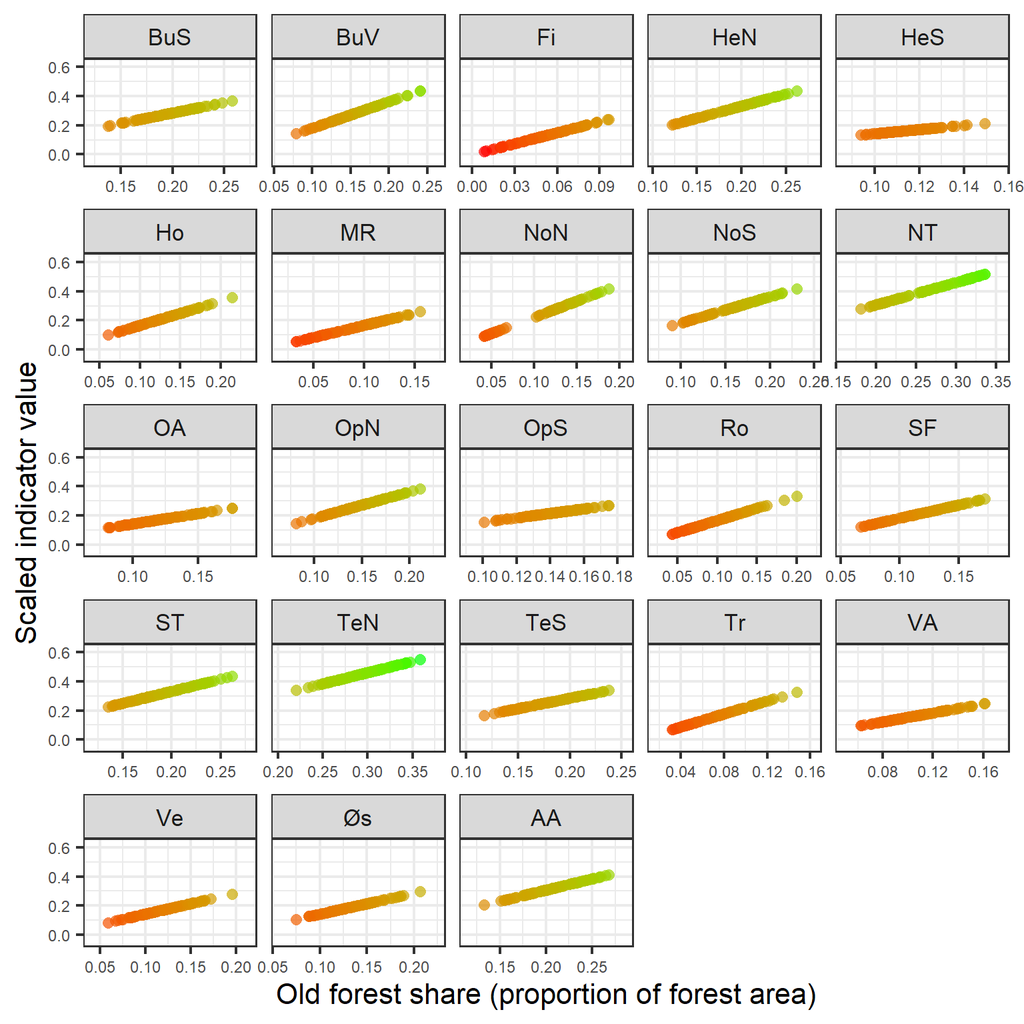

```r
norm_plot_data <- county_draws_scaled |>
  dplyr::group_by(county_part) |>
  dplyr::slice_sample(n = 100) |>
  dplyr::ungroup()

bgsk_norm_plot <- ec_norm_plot(norm_plot_data$non_scaled_value, norm_plot_data$scaled_value) +
  ggplot2::facet_wrap(~ norm_plot_data$county_part, scales = "free_x") +
  ggplot2::labs(
    x = "Old forest share (proportion of forest area)",
    y = "Scaled indicator value"
  ) +
  ggplot2::theme(axis.text = ggplot2::element_text(size = 9))
bgsk_norm_plot$layers[[1]]$aes_params$size <- 3

suppressMessages(
  ggsave(
    filename = here::here("img/bgsk_norm_plot.png"),
    plot = bgsk_norm_plot,
    scale = 1.5
  )
)

bgsk_norm_plot
```

The scaled draws are then passed to `ecTools::ec_upscale()`, which propagates uncertainty through the spatial hierarchy. For each of 1000 Monte Carlo iterations, one draw is sampled per county and the area-weighted mean gives one regional value; a second `ecTools::ec_upscale()` call repeats this from regions to national level.

**ec_upscale: county to region (compute once, save RDS)**

```r
bgsk_mc_cache_deps <- c(
  here::here("data/LSK_data_okologisk_tilstand_2026-06-03.csv"),
  here::here("R/functions.R"),
  here::here("R/NO_BGSK_001.qmd")
)
bgsk_mc_rds_regional <- here::here("data/bgsk_mc_regional.rds")

if (
  file.exists(bgsk_mc_rds_regional) &&
  file.mtime(bgsk_mc_rds_regional) >= max(file.mtime(bgsk_mc_cache_deps), na.rm = TRUE)
) {
  bgsk_mc_regional <- readRDS(bgsk_mc_rds_regional)
} else {
  bgsk_mc_regional <- ecTools::ec_upscale(
    data        = county_draws_scaled,
    variable    = scaled_value,
    weight      = total_area,
    start_units = fylke_name,
    end_units   = region_code,
    year        = period,
    end_units_name = "region_code",
    n = 1000
  )
  saveRDS(bgsk_mc_regional, bgsk_mc_rds_regional)
}
```

**ec_upscale: region to national (compute once, save RDS)**

```r
region_area_weights <- county_draws_scaled |>
  dplyr::distinct(period, fylke_name, total_area, region_code) |>
  dplyr::group_by(period, region_code) |>
  dplyr::summarise(region_area = sum(total_area), .groups = "drop")

bgsk_mc_regional_for_national <- bgsk_mc_regional |>
  dplyr::left_join(region_area_weights, by = c("period", "region_code")) |>
  dplyr::mutate(nation = "National")

bgsk_mc_rds_national <- here::here("data/bgsk_mc_national.rds")

if (
  file.exists(bgsk_mc_rds_national) &&
  file.mtime(bgsk_mc_rds_national) >= max(
    c(file.mtime(bgsk_mc_cache_deps), file.mtime(bgsk_mc_rds_regional)),
    na.rm = TRUE
  )
) {
  bgsk_mc_national <- readRDS(bgsk_mc_rds_national)
} else {
  bgsk_mc_national <- ecTools::ec_upscale(
    data        = bgsk_mc_regional_for_national,
    variable    = sampled_mean,
    weight      = region_area,
    start_units = region_code,
    end_units   = nation,
    year        = period,
    end_units_name = "nation",
    n = 1000
  )
  saveRDS(bgsk_mc_national, bgsk_mc_rds_national)
}
```

**Combine regional and national MC draws; build summary tables**

```r
bgsk_mc_combined <- dplyr::bind_rows(
  bgsk_mc_regional |> dplyr::select(period, region = region_code, sampled_mean),
  bgsk_mc_national |> dplyr::select(period, region = nation, sampled_mean)
)

county_scaled_all_periods <- bgsk_results_county_all_periods |>
  dplyr::left_join(county_reference, by = "county_part") |>
  dplyr::filter(!is.na(x100)) |>
  dplyr::mutate(
    scaled_value = ec_normalise(indicator_value, x0 = x0, x100 = x100, fun = "linear")
  )

region_scaled_agg_all_periods <- bgsk_mc_regional |>
  dplyr::group_by(period, region_code) |>
  dplyr::summarise(scaled_value = median(sampled_mean), .groups = "drop") |>
  dplyr::mutate(region_name = assign_region_name(region_code))

national_scaled_agg_all_periods <- bgsk_mc_national |>
  dplyr::group_by(period) |>
  dplyr::summarise(scaled_value = median(sampled_mean), .groups = "drop") |>
  dplyr::mutate(region = "National")

region_scaled_agg_with_uncertainty <- bgsk_mc_regional |>
  dplyr::group_by(period, region_code) |>
  dplyr::summarise(
    median = median(sampled_mean),
    p_025  = as.numeric(quantile(sampled_mean, 0.025)),
    p_25   = as.numeric(quantile(sampled_mean, 0.25)),
    p_75   = as.numeric(quantile(sampled_mean, 0.75)),
    p_975  = as.numeric(quantile(sampled_mean, 0.975)),
    .groups = "drop"
  ) |>
  dplyr::mutate(region_name = assign_region_name(region_code)) |>
  dplyr::left_join(
    bgsk_results_region_all_periods |> dplyr::select(period, region_code, total_area, n_plots),
    by = c("period", "region_code")
  )

national_scaled_agg_with_uncertainty <- bgsk_mc_national |>
  dplyr::group_by(period) |>
  dplyr::summarise(
    median = median(sampled_mean),
    p_025  = as.numeric(quantile(sampled_mean, 0.025)),
    p_25   = as.numeric(quantile(sampled_mean, 0.25)),
    p_75   = as.numeric(quantile(sampled_mean, 0.75)),
    p_975  = as.numeric(quantile(sampled_mean, 0.975)),
    .groups = "drop"
  ) |>
  dplyr::mutate(region = "National") |>
  dplyr::left_join(
    bgsk_results_national_all_periods |> dplyr::select(period, total_area, n_plots),
    by = "period"
  )

truncation_summary <- dplyr::bind_rows(
  county_scaled_all_periods |>
    dplyr::left_join(
      bgsk_reference_values |> dplyr::select(county_part, reference_value_pct = x100_pct),
      by = "county_part"
    ) |>
    dplyr::mutate(
      level = "County",
      exceeds_threshold = indicator_value > x100,
      original_value_pct = round(indicator_value * 100, 2),
      region_code = NA_character_,
      region_name = NA_character_
    ) |>
    dplyr::select(
      period, level, region_code, region_name, fylke_name,
      reference_value_pct, exceeds_threshold, original_value_pct
    ),
  region_scaled_agg_all_periods |>
    dplyr::left_join(
      bgsk_results_region_all_periods |> dplyr::select(period, region_code, indicator_value),
      by = c("period", "region_code")
    ) |>
    dplyr::mutate(
      level = "Region",
      exceeds_threshold = scaled_value >= 1,
      original_value_pct = round(indicator_value * 100, 2),
      reference_value_pct = NA_real_,
      fylke_name = NA_character_
    ) |>
    dplyr::select(
      period, level, region_code, region_name, fylke_name,
      reference_value_pct, exceeds_threshold, original_value_pct
    ),
  national_scaled_agg_all_periods |>
    dplyr::left_join(
      bgsk_results_national_all_periods |> dplyr::select(period, indicator_value),
      by = "period"
    ) |>
    dplyr::mutate(
      level = "National",
      exceeds_threshold = scaled_value >= 1,
      original_value_pct = round(indicator_value * 100, 2),
      reference_value_pct = NA_real_,
      region_code = NA_character_,
      region_name = "National",
      fylke_name = NA_character_
    ) |>
    dplyr::select(
      period, level, region_code, region_name, fylke_name,
      reference_value_pct, exceeds_threshold, original_value_pct
    )
)

truncation_counts <- truncation_summary |>
  dplyr::group_by(period, level) |>
  dplyr::summarise(
    n_total = dplyr::n(),
    n_exceeding_reference = sum(exceeds_threshold, na.rm = TRUE),
    pct_exceeding_reference = round(100 * n_exceeding_reference / n_total, 1),
    .groups = "drop"
  )

truncated_values <- truncation_summary |>
  dplyr::filter(exceeds_threshold) |>
  dplyr::arrange(period, level, dplyr::desc(original_value_pct))
```

At county or sub-county level, truncation is evaluated by comparing the non-scaled point estimate to the matching *X<sub>100</sub>*. At regional and national level, the tables report cases where the `ecTools::ec_upscale()` median equals 1. The following tables summarise how often truncation occurred in each period and list the affected units.

| Period | Level | Total | Exceeding reference | % Exceeding reference |
| --- | --- | --- | --- | --- |
| 2010-2014 | County | 23 | 0 | 0.0 |
| 2010-2014 | National | 1 | 0 | 0.0 |
| 2010-2014 | Region | 5 | 0 | 0.0 |
| 2015-2019 | County | 23 | 0 | 0.0 |
| 2015-2019 | National | 1 | 0 | 0.0 |
| 2015-2019 | Region | 5 | 0 | 0.0 |
| 2020-2024 | County | 23 | 0 | 0.0 |
| 2020-2024 | National | 1 | 0 | 0.0 |
| 2020-2024 | Region | 5 | 0 | 0.0 |

```
No values exceeded their reference and required truncation.
```

The time series below (Figure 2) summarises regional and national values.

**Time series of indicator values by region and period**

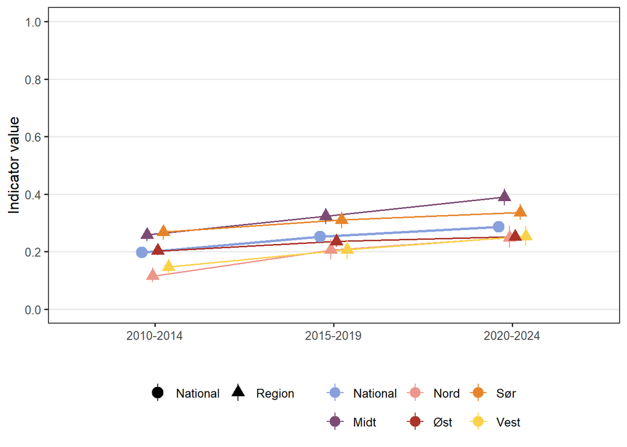

Figure 2: Indicator values for biologically old forest share by region and reporting period. Points show the MC median; error bars are 95% credible intervals from the Monte Carlo propagation. National values use filled circles and a thicker line.

```r
bgsk_region_labels <- c(
  "1" = "Øst", "2" = "Sør", "3" = "Vest",
  "4" = "Midt", "5" = "Nord", "National" = "National"
)
bgsk_region_levels <- c("National", "Midt", "Nord", "Øst", "Sør", "Vest")
bgsk_region_cols <- setNames(
  MetBrewer::met.brewer("Archambault", n = length(bgsk_region_levels)),
  bgsk_region_levels
)

bgsk_plot_data <- bgsk_mc_combined |>
  dplyr::mutate(
    region_name = dplyr::recode(region, !!!bgsk_region_labels),
    series_type = dplyr::if_else(region == "National", "National", "Region")
  ) |>
  dplyr::group_by(period, region_name, series_type) |>
  dplyr::summarise(
    median = median(sampled_mean),
    p_025  = as.numeric(quantile(sampled_mean, 0.025)),
    p_975  = as.numeric(quantile(sampled_mean, 0.975)),
    .groups = "drop"
  ) |>
  dplyr::mutate(region_name = factor(region_name, levels = bgsk_region_levels))

ggplot2::ggplot(
  bgsk_plot_data,
  ggplot2::aes(x = period, y = median, colour = region_name, group = region_name)
) +
  ggplot2::geom_line(
    ggplot2::aes(linewidth = series_type),
    position = ggplot2::position_dodge(width = 0.18)
  ) +
  ggplot2::geom_pointrange(
    ggplot2::aes(ymin = p_025, ymax = p_975, shape = series_type),
    size = 0.8, linewidth = 0.45,
    position = ggplot2::position_dodge(width = 0.18)
  ) +
  ggplot2::scale_colour_manual(values = bgsk_region_cols, name = NULL) +
  ggplot2::scale_shape_manual(values = c(National = 19, Region = 17), name = NULL) +
  ggplot2::scale_linewidth_manual(values = c(National = 1, Region = 0.55), guide = "none") +
  ggplot2::scale_y_continuous(limits = c(0, 1), breaks = seq(0, 1, 0.2)) +
  ggplot2::theme_bw(base_size = 12) +
  ggplot2::theme(
    legend.position    = "bottom",
    legend.box         = "horizontal",
    panel.grid.minor   = ggplot2::element_blank(),
    panel.grid.major.x = ggplot2::element_blank()
  ) +
  ggplot2::guides(
    colour = ggplot2::guide_legend(
      nrow = 2,
      override.aes = list(size = 0.7, linewidth = 0.45)
    ),
    shape  = ggplot2::guide_legend(override.aes = list(size = 0.8, linewidth = 0.45))
  ) +
  ggplot2::labs(y = "Indicator value", x = "")
```

## 10. Results

The following tables present scaled indicator results at county or sub-county, regional, and national scales for each reporting period. Tables report the median as the indicator value, with an approximate 95% interval (2.5% and 97.5% quantiles) and an approximate interquartile range (25% and 75% quantiles).

### 10.1 County-level results (scaled with uncertainty)

Use the search box and page controls in Table 3 to browse county rows across all reporting periods.

Table 3: County or sub-county indicator values for biologically old forest share by reporting period. Values are scaled to 0–1 using county-specific *X<sub>0</sub>* and *X<sub>100</sub>* via `ecTools::ec_normalise()`. Uncertainty is derived from 1000 bootstrap draws scaled with the same function (section 9.3–9.4). The median is reported as the indicator value, with approximate 95% and interquartile intervals from the scaled draw distribution.

[output not shown]

[output cut: 59 more lines]

### 10.2 Regional results (scaled with uncertainty)

Table 4: Regional indicator values for biologically old forest share by reporting period. Scaled values and uncertainty are derived from ecTools::ec_upscale() Monte Carlo propagation (1000 draws per region per period). The median is reported as the indicator value, with approximate 95% and interquartile intervals from the MC distribution.

| ECT | Indicator | ID | Accounting area | Ecosystem | Reporting period | Indicator value | 95% CI | 50% CI | Number of plots |
| --- | --- | --- | --- | --- | --- | --- | --- | --- | --- |
| C1 | Biologically old forest share | NO_BGSK_001 | Øst | Boreal/montane forests | 2010-2014 | 0.20 | 0.19 - 0.22 | 0.2 - 0.21 | 4,769 |
| C1 | Biologically old forest share | NO_BGSK_001 | Sør | Boreal/montane forests | 2010-2014 | 0.27 | 0.24 - 0.29 | 0.26 - 0.28 | 1,899 |
| C1 | Biologically old forest share | NO_BGSK_001 | Vest | Boreal/montane forests | 2010-2014 | 0.15 | 0.12 - 0.17 | 0.14 - 0.16 | 1,243 |
| C1 | Biologically old forest share | NO_BGSK_001 | Midt | Boreal/montane forests | 2010-2014 | 0.26 | 0.23 - 0.28 | 0.25 - 0.27 | 2,384 |
| C1 | Biologically old forest share | NO_BGSK_001 | Nord | Boreal/montane forests | 2010-2014 | 0.11 | 0.09 - 0.14 | 0.11 - 0.12 | 2,172 |
| C1 | Biologically old forest share | NO_BGSK_001 | Øst | Boreal/montane forests | 2015-2019 | 0.24 | 0.22 - 0.25 | 0.23 - 0.24 | 4,764 |
| C1 | Biologically old forest share | NO_BGSK_001 | Sør | Boreal/montane forests | 2015-2019 | 0.31 | 0.28 - 0.34 | 0.3 - 0.32 | 1,907 |
| C1 | Biologically old forest share | NO_BGSK_001 | Vest | Boreal/montane forests | 2015-2019 | 0.21 | 0.17 - 0.24 | 0.19 - 0.22 | 1,254 |
| C1 | Biologically old forest share | NO_BGSK_001 | Midt | Boreal/montane forests | 2015-2019 | 0.32 | 0.3 - 0.35 | 0.31 - 0.33 | 2,390 |
| C1 | Biologically old forest share | NO_BGSK_001 | Nord | Boreal/montane forests | 2015-2019 | 0.21 | 0.17 - 0.24 | 0.19 - 0.22 | 2,242 |
| C1 | Biologically old forest share | NO_BGSK_001 | Øst | Boreal/montane forests | 2020-2024 | 0.25 | 0.24 - 0.27 | 0.25 - 0.26 | 4,795 |
| C1 | Biologically old forest share | NO_BGSK_001 | Sør | Boreal/montane forests | 2020-2024 | 0.34 | 0.31 - 0.36 | 0.33 - 0.35 | 1,908 |
| C1 | Biologically old forest share | NO_BGSK_001 | Vest | Boreal/montane forests | 2020-2024 | 0.25 | 0.22 - 0.29 | 0.24 - 0.26 | 1,272 |
| C1 | Biologically old forest share | NO_BGSK_001 | Midt | Boreal/montane forests | 2020-2024 | 0.39 | 0.36 - 0.42 | 0.38 - 0.4 | 2,391 |
| C1 | Biologically old forest share | NO_BGSK_001 | Nord | Boreal/montane forests | 2020-2024 | 0.25 | 0.21 - 0.29 | 0.24 - 0.26 | 2,241 |

### 10.3 National results (scaled with uncertainty)

Table 5: National indicator values for biologically old forest share by reporting period. Scaled values and uncertainty are derived from ecTools::ec_upscale() Monte Carlo propagation (1000 draws). The median is reported as the indicator value, with approximate 95% and interquartile intervals from the MC distribution.

| ECT | Indicator | ID | Accounting area | Ecosystem | Reporting period | Indicator value | 95% CI | 50% CI | Number of plots |
| --- | --- | --- | --- | --- | --- | --- | --- | --- | --- |
| C1 | Biologically old forest share | NO_BGSK_001 | National | Boreal/montane forests | 2010-2014 | 0.20 | 0.19 - 0.21 | 0.19 - 0.2 | 12,467 |
| C1 | Biologically old forest share | NO_BGSK_001 | National | Boreal/montane forests | 2015-2019 | 0.25 | 0.24 - 0.26 | 0.25 - 0.26 | 12,557 |
| C1 | Biologically old forest share | NO_BGSK_001 | National | Boreal/montane forests | 2020-2024 | 0.29 | 0.27 - 0.3 | 0.28 - 0.29 | 12,607 |

## 11. Export file

Regional and national Monte Carlo draws are exported in one table (`bgsk_mc_combined`: `period`, `region`, `sampled_mean`).

**Export regional and national MC-propagated indicator draws**

```r
write.csv(
  bgsk_mc_combined,
  here::here("data/results_NO_BGSK_001.csv"),
  row.names = FALSE
)
```

## 12. Author contributions

**CRediT statement**

- Conceptualization: [KOS, EF, UJA]
- Methodology: [EF, KOS, UJA]
- Data curation: [OS]
- Formal analysis: [AHH]
- Validation: [AHH, KOS]
- Visualization: [AHH]
- Writing – original draft: [AHH, EF]
- Writing – review & editing: [All]

MeRIT attribution

This part supplements the CRediT statement with more granularity for method section.

**TipSession Info**

This workflow uses `renv`. Run `renv::restore()` to recreate the working environment.